# Module 3 Project, Part E: Check Your Numbers

This is the output of one complete run of the project, with a fixed random seed. Use it to see whether your own results are in the right ballpark: the same order of magnitude, the same conclusions, the same first digit or two. It is not an answer key. There is no code and no explanation here, and the exam asks about *your* project, not this one.

What should match, and how closely:

- **Exact values** do not depend on random numbers and should match to every digit shown: the group sizes, the observed nearest-neighbor counts, the SDs, $r$, dCor, the dCov ratio, the table, the midranks and the `wilcox.test` $p$-value.
- **Permutation results** vary from run to run. Your null means and $p$-values should agree with these to about two significant digits, and lead to the same conclusions at 5%.

```
##      type   n
## 1 holiday  21
## 2 weekend 210
## 3 working 500
```

# Part E: Permutation tests for vectors and tables

## E.1

Rentals by type of day, the energy test’s $p$-value for holidays against weekends and against working days, and the two null distributions.

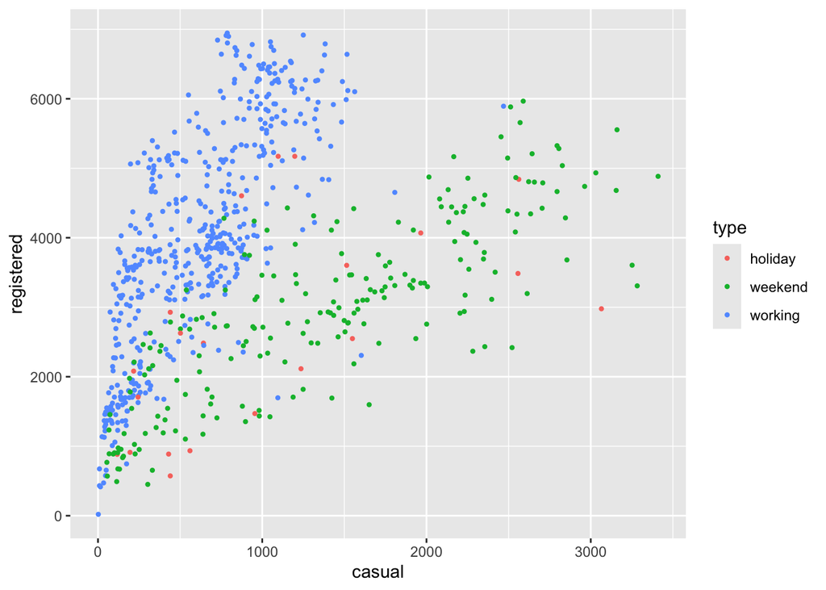

```
##      weekend      working
## 0.1479260370 0.0004997501
```

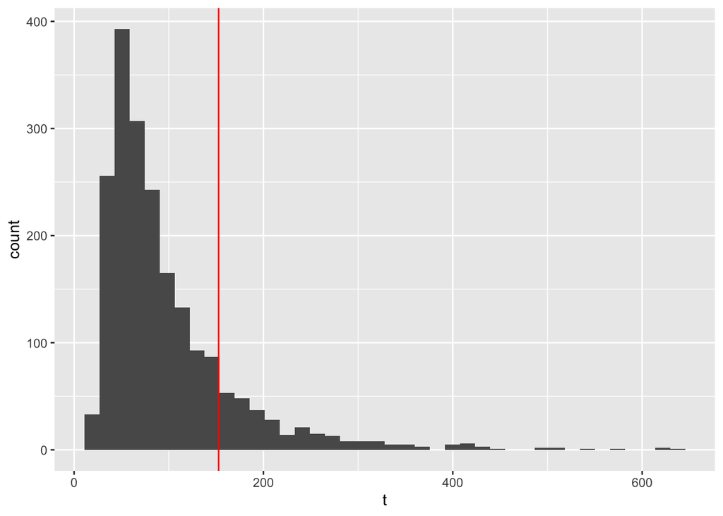

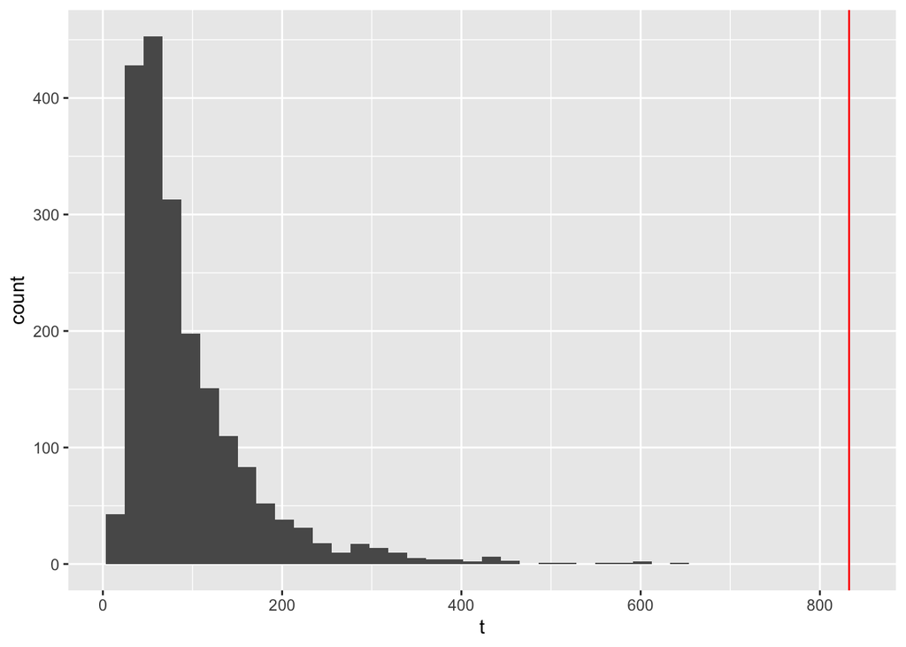

## E.2

Rentals against humidity, $r$ and its permutation $p$-value and null distribution, dCor with the largest null value, its $p$-value and null distribution, then $r$ below and above 60% humidity.

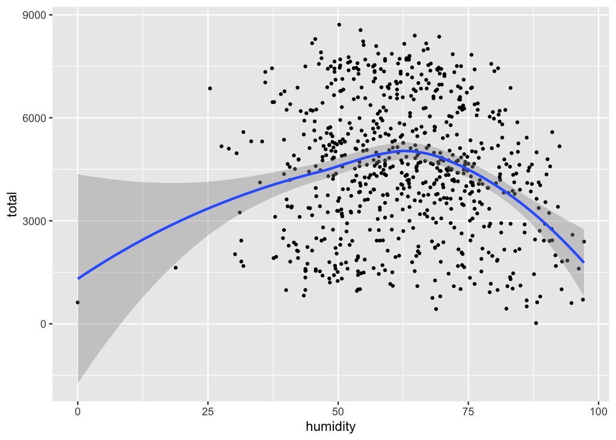

```
##            r            p
## -0.100610548  0.006996502
```

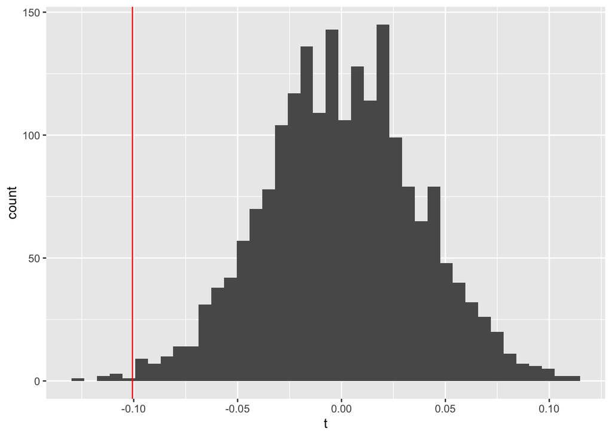

```
##      dcor  max_null         p
## 0.1670348 0.1320158 0.0010000
```

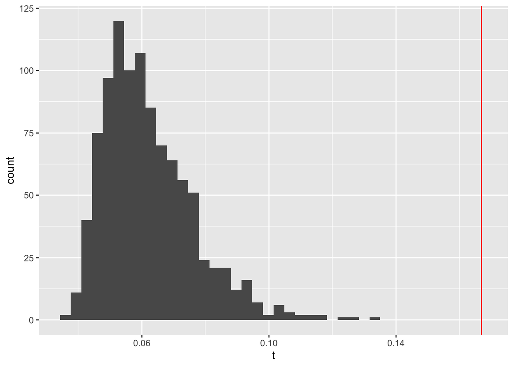

```
##   below_60   above_60
##  0.1763000 -0.3477646
```

## E.3(a)

For holidays against working days: the nearest-neighbor count over all days and over holidays only, the SDs of the two columns, then the energy test and the two nearest-neighbor tests after `scale()`.

```
##                all holiday
## observed  495.0000  7.0000
## null_mean 480.6220  0.7925
## p           0.0005  0.0005
```

```
##     casual registered
## 1 428.5599   1585.383
```

```
## [1] 0.0004997501
```

```
##                all holiday
## observed  487.0000   5.000
## null_mean 480.6190   0.809
## p           0.0705   0.008
```

## E.3(b)

The ratio of dCov to the energy statistic, and $2(mn/N^2)^2$.

```
##      ratio    formula
## 0.01366027 0.01366027
```

## E.3(c)

The table of weather against working day, the midranks, the midranks from the counts, the two $p$-values, and the null distribution of $W$.

```
##        workingday
## weather   0   1
##       1 156 307
##       2  70 177
##       3   5  16
```

```
## [1] 232 587 721
```

```
##   weather   n from_n
## 1       1 463    232
## 2       2 247    587
## 3       3  21    721
```

```
## permutation      wilcox
##  0.09522619  0.10124158
```

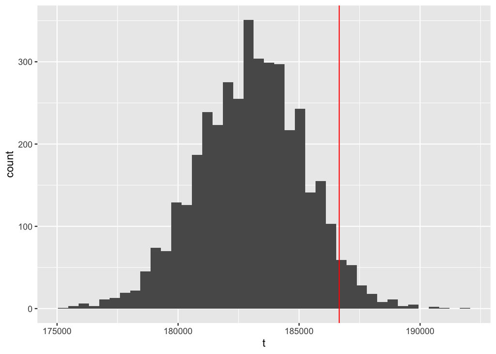